# Section 10

Chris Carter

April 1, 2019

# Today: Beyond OLS

- OLS vs GLS vs GLM: What are they? How are they alike? Different?
- Deriving and plotting the likelihood function
- Finding the MLE and its SE
- Reporting MLE results
- Let’s go back to OLS.
- A first concern was assumptions on the disturbances (or errors)
- What are those assumptions?

# GLS

- With GLS, we assume that the $cov(\epsilon|X) = G$
- $\hat{\beta}_{GLS} = \beta + (X'G^{-1}X)^{-1}X'G^{-1}\epsilon$. Is this conditionally unbiased?
- $cov(\hat{\beta}_{GLS}|X) = (X'G^{-1}X)^{-1}$
- $cov(\hat{\beta}_{fGLS}|X) = (X'\hat{G}^{-1}X)^{-1}$
- Often, $\hat{\beta}_{FGLS}$ will be biased. Why?

# MLE

- What else do we assume in OLS? Think about the model itself.
- Sometimes we think linearity is an unrealistic assumption.
- What are we trying to minimize or maximize in OLS?
- Here, we are trying to maximize a likelihood.
- And remember, we are still trying to estimate parameters.

What if we try to estimate the following?

$$P(Y=1|X) = X\beta$$

- We can instead estimate
  $$P(Y=1|X) = F(X\beta)$$
  ,
  $$P(Y=0|X) = 1 - F(X\beta)$$
  , and
  $$P(Y|X) = F(X\beta)^{y} (1-F(X\beta))^{1-y}$$
- $$log(\prod_{i=1}^n p^{X_{i}}(1-p)^{1-X_{i}})$$
- $$\sum_{i=1}^n log(p^{X_{i}}(1-p)^{1-X_{i}})$$
- $$\sum_{i=1}^n \Big[ X_{i}log(p) + (1-X_{i})log(1-p))\Big]$$
- $$log(p)\sum_{i=1}^n X_{i} + log(1-p)\sum_{i=1}^n(1-X_{i})$$
- $$log(p)n\bar{X} + log(1-p)(n-n\bar{X})$$
- Now, we can take a derivative of the log likelihood function ($L_{n}(p)$) with respect to $\hat{p}$, our sample estimate of $p$.

$$\frac{\partial logL}{\partial p} = 0 = \frac{n\bar{X}}{p}-\frac{n-n\bar{X}}{1-p}$$

$$n\bar{X}(1-p) = p(n-n\bar{X})$$
$$p = \bar{X}$$

# Probit

Probit functions take the following form:
$$P(Y_{i}=0|X) = 1- \Phi(X_{i}\beta), \text{ } P(Y_{i}=1|X)= \Phi(X_{i}\beta)$$

where $\Phi$ is the link function. What does that mean?

- Let’s say we want to know what factors affect a person’s likelihood of having health care. Our outcome is thus whether an individual has health care. We measure age, education, and partisanship. Thus, for a person, whose fifty years old with twelve years of education and is a republican, we can generate a predicted $Y_{i}$ by using $\Phi(\beta_{age}\times 50 + \beta_{ed}\times 12 + \beta_{republican})$. If we assume that the link function is standard normal, then we can calculate a predicted probability using the cumulative distribution function of the standard normal. What probability value in the CDF corresponds to the observed value?

Latent variables formulation

Has health care if:
$$X_{i}\beta + U_{i} > 0$$

- $$P(Y_{i} = 1|X) = P(X_{i}\beta + U_{i} > 0)$$
- $$P(Y_{i} = 1|X) = P(U_{i} < X_{i}\beta)$$
- Under what assumption about the latent variable, $U$, is this equivalent to the probit?

# Logit

- Stochastic component:
  $$Y_i \sim Y_{Bernoulli}(y_i|\pi_i) = (\pi_i)^{y_i} (1-\pi_i)^{(1-y_i)}$$
- But what is $\pi_i$? For that we need a link function.
- In a logit, we use a different distribution function (instead of the normal): $\Lambda(x) = \frac{e^x}{1+e^x}$

# The Logistic Link Function

Systematic component:

$$\sigma(x) = \frac{1}{1+e^{-x}} = \frac{e^x}{1+e^x}$$

Note that
$$\sigma(x) \in [0,1]$$
for all $x$

We can program this:

```r
logistic <- function(x){ exp(x) / (1 + exp(x)) }
```

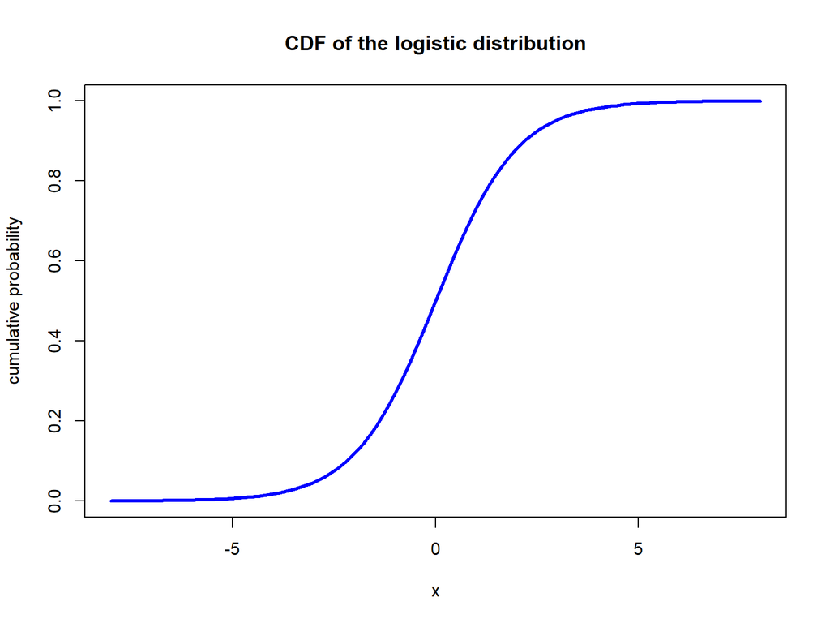

```r
curve(logistic(x), xlim=c(-8, 8), xlab="x", main="CDF of the logistic distribution",
      ylab="cumulative probability", col="blue", lwd=3)
```

- In a logit, $L = \prod_{i=1}^n [\Lambda(X\beta)]^{y_{i}}[1-\Lambda(X\beta)]^{1-y_{i}}$ and find values of $\hat{\beta}$ that maximize $L$.
- With covariates, we have
  $$\Lambda(X\beta) = \frac{1}{1+e^{-X\beta}} = \frac{e^{X\beta}}{1+e^{X\beta}}$$
- So:
  $$P(y_i=1|\beta) = \pi_i= \frac{1}{1+e^{-X\beta}}$$
  $$P(y_i=0|\beta) = 1 - \pi_i= 1 - (\frac{1}{1+e^{-X\beta}})$$

A small dataset

```r
Y <- c(1, 0, 1, 0, 0, 1, 1)
x <- c(.5, .3, .45, .4, .25, .7, .9)

cbind(Y, x)
```

```
##      Y    x
## [1,] 1 0.50
## [2,] 0 0.30
## [3,] 1 0.45
## [4,] 0 0.40
## [5,] 0 0.25
## [6,] 1 0.70
## [7,] 1 0.90
```

$$P(y|\pi) = \prod_{i=1}^{n} \pi^{y_i} (1-\pi_i)^{1-y_i}$$

- where $\pi_i = \Lambda(x_i\beta) = \frac{1}{1+e^{-x_i\beta}}$
- And so the likelihood is
  $$L = P(y|X\beta) = \prod_{i=1}^{n} \Lambda(x_i\beta)^{y_i} (1-\Lambda(x_i\beta))^{1-y_i}$$
- And the log-likelihood
  $$lnL = \sum_{i=1}^{n} y_i * ln[\Lambda(x_i\beta)] + (1-y_i) * ln[1-\Lambda(x_i\beta)]$$

The derivative of this has no closed-form solution and thus we need to iterate to find the $\hat{\beta}$ that maximizes lnL.

We can program the likelihood in `R`:

```r
LL <- function(beta, x, y){

    odds <- beta * x

    rate <- 1 / (1 + exp(-odds))

    sum( y * log(rate) + (1 - y) * log(1 - rate) )
}
```

And we can plot the log-likelihood of our fake data:

```r
LL_example <- function(x){

    odds <- x * c(.5, .3, .4, .4, .25)

    rate <- 1 / (1 + exp(-odds))

    y <- c(1, 0, 1, 0, 0)

    sum(ifelse(y==1, log(rate), log(1 - rate)))

}

betas <- seq(-10, 10, by=.01)
ll_betas <- unlist(lapply(betas, FUN=LL_example)) # no intercept here
```

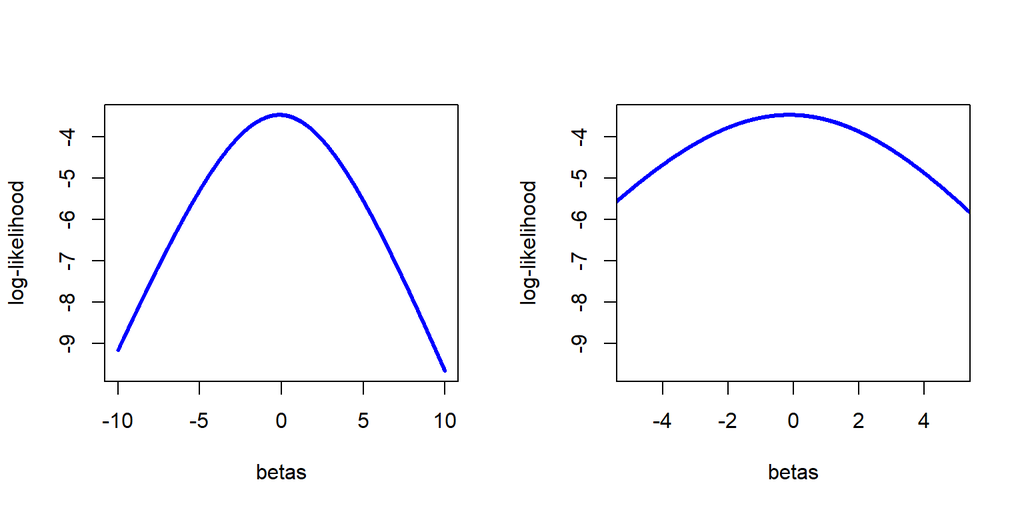

```r
par(mfrow=c(1,2))
plot(betas, ll_betas, col="blue", type="l", lwd=3, ylab="log-likelihood")
plot(betas, ll_betas, col="blue", type="l", lwd=3, ylab="log-likelihood", xlim=c(-5, 5))
```

What’s the value of $\beta$ tha maximizes the log-likelihood?

Getting the MLE.

```r
beta.start <- 0
out  <-  optim(beta.start,
            fn=LL,
            x=x,y=Y,
            hessian=T,
            method="L-BFGS-B",
            control=list(fnscale=-1))
out
```

```
## $par
## [1] 1.732208
##
## $value
## [1] -4.197606
##
## $counts
## function gradient
##        7        7
##
## $convergence
## [1] 0
##
## $message
## [1] "CONVERGENCE: REL_REDUCTION_OF_F <= FACTR*EPSMCH"
##
## $hessian
##            [,1]
## [1,] -0.3701616
```

```r
mle <- out$par
mle
```

```
## [1] 1.732208
```

```r
glm(Y~0+x, family=binomial(logit))
```

```
##
## Call:  glm(formula = Y ~ 0 + x, family = binomial(logit))
##
## Coefficients:
##     x
## 1.732
##
## Degrees of Freedom: 7 Total (i.e. Null);  6 Residual
## Null Deviance:       9.704
## Residual Deviance: 8.395     AIC: 10.4
```

```r
##Fisher information (-H^-1)
vcov <- -solve(out$hessian)
```

# How should we present the results?

1. Simulate betas

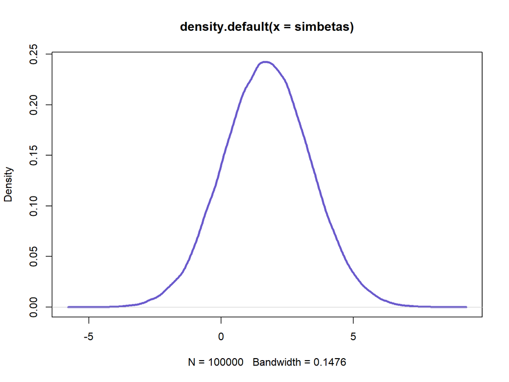

```r
simbetas <- rnorm(100000, mle, sqrt(vcov))
par(mfrow=c(1,1))
plot(density(simbetas), col="slateblue", lwd=3)
```

2. Simulate predicted value

Let’s say we get econ data for one more observation and we want to predict the probability of $y=1$

```r
new_obs <- .45 # our new data point

cov <- simbetas * new_obs
pred.p <- 1 / (1+exp(-cov))
mean(pred.p)
```

```
## [1] 0.6672942
```

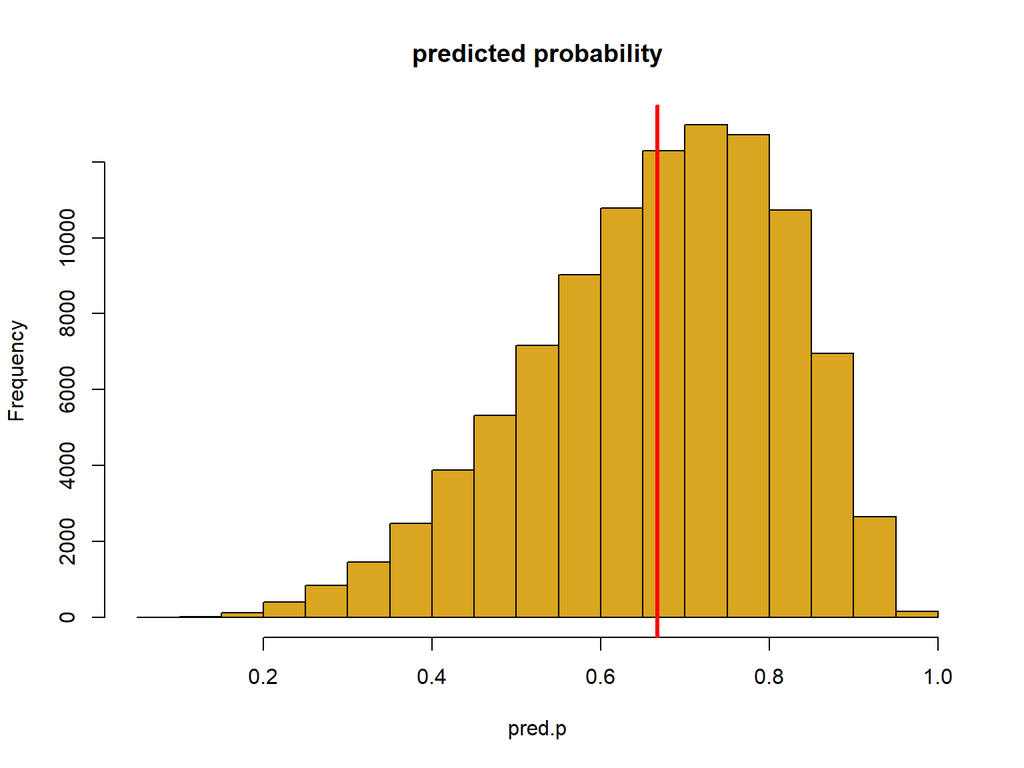

```r
hist(pred.p, col="goldenrod", main="predicted probability")
abline(v=mean(pred.p), col="red", lwd=3)
```

```r
quantile(pred.p, probs = c(0.25, 0.75))
```

```
##       25%       75%
## 0.5694032 0.7815512
```

3. Simulate expected values

```r
# for the binomial distribution, the expected value equals
# the rate, so to get the expected value we can just take
# the expectation of the predicted probabilities (for other
# distributions this might not hold, and we might want to
# do the simulation of the stochastic component as well)
# so here we could just do
mean(pred.p)
```

```
## [1] 0.6672942
```

Simulate first differences

```r
new_obs
```

```
## [1] 0.45
```

```r
new_obs.better <- 0.65

cov <- simbetas * new_obs.better
pred.p.2 <- 1 / (1 + exp(-cov))

# to get the expected value, here we can again just take the
# mean of the predicted probabilities
mean(pred.p.2)
```

```
## [1] 0.7146943
```

```r
#now lets get the first difference
firs.diff <- mean(pred.p.2) - mean(pred.p)
firs.diff
```

```
## [1] 0.04740011
```

An increase in the independent variable is associated with an increase in the outcome.

Predicted probabilities plot

How would we do the plot of predicted probabilities?

```r
# Let's take values of X from -1 to 1
x_sim <- seq(-1, 1, by=.01)

pred.prob <- matrix(NA, length(x_sim), 3)

for(i in 1:length(x_sim)){

    cov <- simbetas * x_sim[i]
    pred.p <- 1/(1+exp(-cov))

    pred.prob[i,1] <- mean(pred.p)
    pred.prob[i,2] <- quantile(pred.p, probs=.05) # lower CI
    pred.prob[i,3] <- quantile(pred.p, probs=.95) # upper CI
}
```

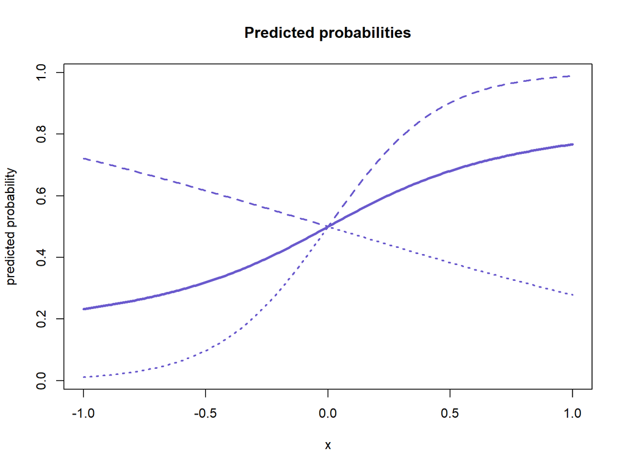

```r
plot(x_sim, pred.prob[,1],
     col="slateblue", type="l",
     lty=1, lwd=3, main="Predicted probabilities",
     xlab="x", ylab="predicted probability", ylim=c(min(pred.prob), max(pred.prob)))
lines(x_sim,pred.prob[,2], col="slateblue", type="l", lty=3, lwd=2 )
lines(x_sim,pred.prob[,3], col="slateblue", type="l", lty=2, lwd=2 )
```